# Analyzing Personal Activity Data

Guennie59

24 September 2017

## Loading and preprocessing the data

Calculating a posix date/time and weekday from it.

That needs a bit a character string manipulation of the interval and pasting together with the date field. Also determining the weekday vs weekendday and adding as extra columns to the dataframe.

```r
library(ggplot2)
library(reshape2)

    PA <- read.csv("activity.csv")

    t_string <- paste("0000",as.character(PA$interval),sep="")
    t_str_len <- nchar(t_string)
    t_string <- substr(t_string, t_str_len-3, t_str_len)
    dt_string <- paste(PA$date,t_string)
    date_time <- strptime(dt_string, format = "%Y-%m-%d %H%M")
    PA$date_time <- date_time
    week_day <- weekdays(date_time, abbreviate = TRUE)
    PA$week_day <- week_day

    week_days = c("Mo","Di","Mi","Do","Fr")
  wd <- PA$week_day
        for (i in 1:17568) {
                if (PA$week_day[i] %in% week_days) {
              wd[i] <- "weekday"} else {wd[i] <- "weekend"
        }
    }

    PA$w_vs_we <- wd
```

## What is mean total number of steps taken per day?

The following code calculates the sum of steps per day via dcast and plots then a histogram of it.

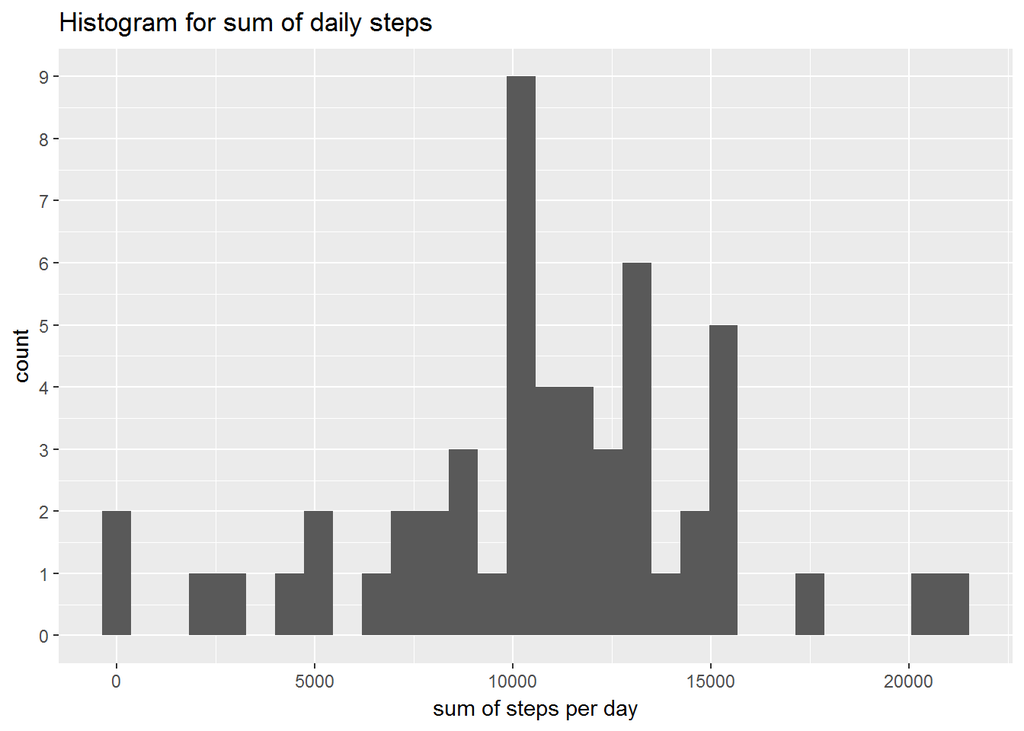

```r
    PA_sum_day <- dcast(PA, date ~ . , fun.aggregate=sum, na.rm = FALSE,
        value.var = "steps")

        PA_hist <- ggplot(data = PA_sum_day, aes(PA_sum_day$.)) +
        geom_histogram() +
        scale_y_continuous(breaks = 0:10) +
        xlab("sum of steps per day") +
        ggtitle("Histogram for sum of daily steps")

        print(PA_hist)
```

Calculating mean and median for the number of steps per day and printing these with explanatory text.

```r
PA_day_sum_mean <- mean(PA_sum_day$., na.rm = TRUE )
PA_day_sum_median <- median(PA_sum_day$., na.rm = TRUE )

print(paste("Mean number of steps per day:",PA_day_sum_mean ))
```

```
## [1] "Mean number of steps per day: 10766.1886792453"
```

```r
print(paste("Median of number of steps per day:",PA_day_sum_median ))
```

```
## [1] "Median of number of steps per day: 10765"
```

## What is the average daily activity pattern?

Determinating the daily activitiy pattern via dcast and creating a time series plot of it.

```r
    PA_mean_int <- dcast(PA, interval ~ . , na.rm = TRUE ,
        value.var = "steps", fun.aggregate=mean)
```

[output not shown]

[figure not shown]

Locating the interval with highest number of steps

```r
    int_max <- which.max(PA_mean_int$.)
  int <- PA_mean_int$interval[int_max]
  print(paste("Maximum steps in interval:", int))
```

```
## [1] "Maximum steps in interval: 835"
```

## Imputing missing values

Imputing missing values now based on the mean steps per 5 minute interval.

A dataframe is being created that has the same size of the original one with mean interval values for all days. Therein all “NA” values are replaced through the corresponding mean.

Plotting the histogram of the new data set.

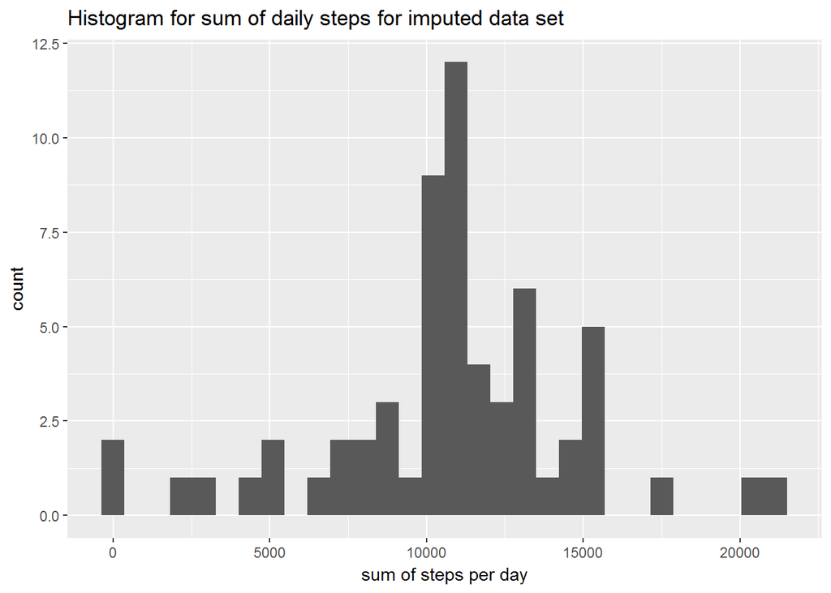

```r
n_days = length(PA_sum_day$.)

PA_means <- PA_mean_int

    for (i in 1:(n_days-1)) {
        PA_means <- rbind(PA_means,PA_mean_int)
    }

    PA_imp <- PA

    for (i in 1:17568) {
        if (PA$steps[i] %in% NA) {
            PA_imp$steps[i] <- PA_means$.[i]
            }
    }
    PA_imp_sum_day <- dcast(PA_imp, date ~ . , fun.aggregate=sum,
        na.rm = FALSE, value.var = "steps")

        PA_imp_sum_day <- dcast(PA_imp, date ~ . , fun.aggregate=sum, na.rm = FALSE,
        value.var = "steps")

        PA_imp_hist <- ggplot(data = PA_imp_sum_day, aes(PA_imp_sum_day$.)) +
        geom_histogram() +
        xlab("sum of steps per day") +
        ggtitle("Histogram for sum of daily steps for imputed data set")

        print(PA_imp_hist)
```

Then Printing the difference in mean and median values. The difference in mean should be zero!

```r
    PA_imp_day_sum_mean <- mean(PA_imp_sum_day$., na.rm = TRUE )
    PA_imp_day_sum_median <- median(PA_imp_sum_day$., na.rm = TRUE )

    day_mean_diff <- PA_imp_day_sum_mean - PA_day_sum_mean
    day_median_diff <- PA_imp_day_sum_median - PA_day_sum_median

    print(paste("Difference of mean after imputing is", day_mean_diff))
```

```
## [1] "Difference of mean after imputing is 0"
```

```r
    print(paste("Difference of median after imputing is", day_median_diff))
```

```
## [1] "Difference of median after imputing is 1.1886792452824"
```

## Are there differences in activity patterns between weekdays and weekends?

Creating a plot thereby separating weekday and weekends through the facet_grid function.

```r
    PA_mean_int_we <- dcast(PA_imp, w_vs_we + interval ~ . , na.rm = TRUE ,
        value.var = "steps", fun.aggregate=mean)
    PA_ts <- ggplot(data=PA_mean_int_we, aes(PA_mean_int_we$interval,
        PA_mean_int_we$.)) + geom_line()    +
        facet_grid(w_vs_we ~ .) +
        xlab("interval") +
        ylab("mean number of steps in interval")
        ggtitle("Timeseries for mean steps")
```

```
## $title
## [1] "Timeseries for mean steps"
##
## $subtitle
## NULL
##
## attr(,"class")
## [1] "labels"
```

```r
    print(PA_ts)
```

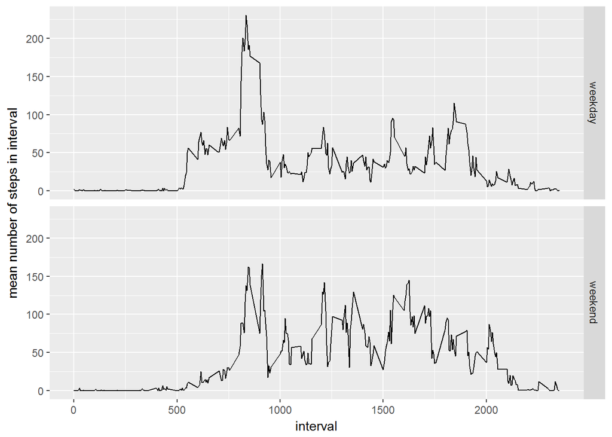

End of the assignment